# RMSC5001 Project 2018-2019 - Classification Tree

CHING, Pui Chi 1155102106 MA, Cheuk Fung 1155106595 YEUNG, Ka Ming 1155104060

2019-05-10

# 1 Introduction

> “The world cannot be understood without numbers. But the world cannot be understood with numbers alone.” ― *Hans Rosling, Factfulness: Ten Reasons We’re Wrong About the World—and Why Things Are Better Than You Think*[^1]

When we were young, teachers often taught us the differences between developed and developing countries. The simplest way to define a country whether it is developed or developing is by GDP per capita. Since 2016, the World Bank is no longer distinguishing the term developed and developing. Instead, the World Bank classify countries by income level: “low-income, lower-middle-income, upper-middle income and high-income economies”. Now we are interested to know which factors contribute to levels of income. We would like to have decision rules and a model to help us to determine the income group of countries.

# 2 Set Up

## 2.1 Library

```r
library(ggplot2)
library(ggthemes)
library(gridExtra)
library(rworldmap)
library(knitr)
library(rpart)
library(rpart.plot)
library(tidyverse)
```

## 2.2 Dataset

We extracted data which cover dependent variables of region, GDP, labor force, life expectancy, military expense, high technology export and corruption for total 177 countries. Some data are missing, for example, military expense, high technology export data and corruption are unknown for some countries in database. We have modified them as zero to setup usable dataset for our case study. We have used income group as the target variable. There are 4 different income groups as prediction results. All the data are retrieved from the World Bank database[^2].

## 2.3 Data field legend

World Bank definition on the income group

| Income.Group | GNI.per.capita |
| --- | --- |
| Low-income | Less than USD 995 |
| Lower-middle income | USD 996 to USD 3,895 |
| Upper-middle income | USD 3,896 to USD12,055 |
| High-income | More than USD 12,055 |

Field information

[output not shown]

## 2.4 Data exploration

```r
d <- read.csv("world.csv", header = TRUE)
n <- nrow(d) # get sample size
set.seed(12345) # set random seed
r <- 0.80 # set sampling ratio
id <- sample(1:n, size = round(r * n)) # generate id
train <- d[id, ] # training dataset
test <- d[-id, ]
head(d)
```

|  | REGION | GDP | LABOUR_FORCE | LIFE_EXPECTANCY | MILITARY_EXPENSE | HIGH_TECHNOLOGY_EXPORT | CORRUPTION | INCOME_GROUP | COUNTRY |
| --- | --- | --- | --- | --- | --- | --- | --- | --- | --- |
| 1 | South Asia | 19543976895 | 13285878 | 64.047 | 0.9068569 | 0 | 2 | Low income | Afghanistan |
| 2 | Europe & Central Asia | 13038538300 | 1333543 | 78.495 | 1.2441751 | 1009999 | 0 | Upper middle income | Albania |
| 3 | Middle East & North Africa | 168000000000 | 12087847 | 76.293 | 5.7082351 | 8180790 | 0 | Upper middle income | Algeria |
| 4 | Sub-Saharan Africa | 122000000000 | 12315755 | 61.809 | 2.2013381 | 0 | 0 | Lower middle income | Angola |
| 5 | Latin America & Caribbean | 637000000000 | 20163928 | 76.738 | 0.9096630 | 1447746846 | 0 | High income | Argentina |
| 6 | Europe & Central Asia | 11536590636 | 1374665 | 74.782 | 3.9680394 | 25601284 | 0 | Upper middle income | Armenia |

## 2.5 Different income levels around the World

```r
income.df <- joinCountryData2Map(d,
  joinCode = "NAME",
  nameJoinColumn = "COUNTRY"
)
```

```
## 171 codes from your data successfully matched countries in the map
## 6 codes from your data failed to match with a country code in the map
## 72 codes from the map weren't represented in your data
```

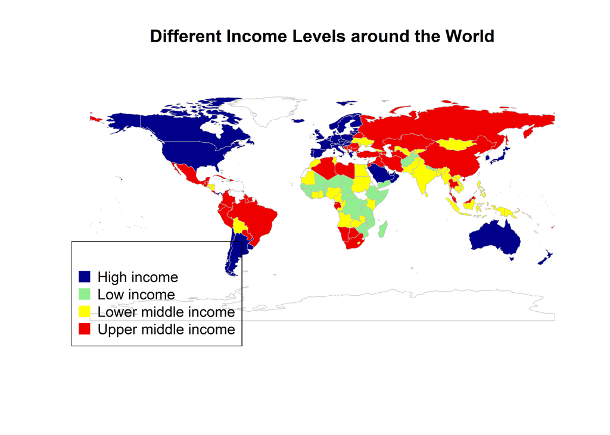

```r
mapParams <- mapCountryData(income.df,
  nameColumnToPlot = "INCOME_GROUP",
  catMethod = "categorical",
  colourPalette = "diverging",
  addLegend = "FALSE",
  mapTitle = "Different Income Levels around the World"
)

do.call(
  addMapLegendBoxes,
  c(mapParams,
    x = "bottomleft",
    horiz = FALSE,
    title = "",
    bg = "NA",
    col = "NA"
  )
)
```

## 2.6 Different income groups probability

```r
# All data
prop.table(table(d$INCOME_GROUP))
```

```
##
##         High income          Low income Lower middle income Upper middle income
##           0.3050847           0.1694915           0.2485876           0.2768362
```

```r
all_plot <- d[, -1] %>%
  count(INCOME_GROUP) %>%
  ggplot() +
  geom_col(aes(x = INCOME_GROUP, y = n),
    fill = "#002244",
    colour = "#002244"
  ) +
  ggtitle("Income group (All data)") +
  coord_flip() +
  theme_fivethirtyeight()

# Training data
prop.table(table(train$INCOME_GROUP))
```

```
##
##         High income          Low income Lower middle income Upper middle income
##           0.2816901           0.1760563           0.2535211           0.2887324
```

```r
train_plot <- train[, -1] %>%
  count(INCOME_GROUP) %>%
  ggplot() +
  geom_col(aes(x = INCOME_GROUP, y = n),
    fill = "#002244",
    colour = "#002244"
  ) +
  ggtitle("Income group (Training data)") +
  coord_flip() +
  theme_fivethirtyeight()

# Testing data
prop.table(table(test$INCOME_GROUP))
```

```
##
##         High income          Low income Lower middle income Upper middle income
##           0.4000000           0.1428571           0.2285714           0.2285714
```

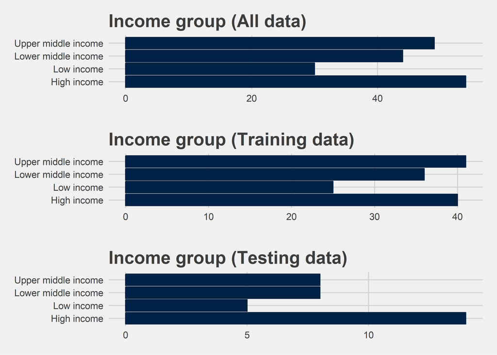

```r
test_plot <- test[, -1] %>%
  count(INCOME_GROUP) %>%
  ggplot() +
  geom_col(aes(x = INCOME_GROUP, y = n),
    fill = "#002244",
    colour = "#002244"
  ) +
  ggtitle("Income group (Testing data)") +
  coord_flip() +
  theme_fivethirtyeight()

grid.arrange(all_plot, train_plot, test_plot, nrow = 3, ncol = 1)
```

# 3 Methodology

Classification is a predictive model. The main use is to utilize the data we have and identify the relevant factors hence classify the out-sample data into correct group and classes. The classification tree was built based on binary splitting of variables, one at a time. Classification tree is trying to construct each terminal node as precise as possible. As such we can easily obtain a set of simple classification rules. Since the building process of CTREE is searching for all possible binary splitting of the variables, it is a complex computation and kind of time consuming.

## 3.1 Classification Tree

```r
ctree <- rpart(INCOME_GROUP ~
REGION + GDP +
  LABOUR_FORCE +
  LIFE_EXPECTANCY +
  MILITARY_EXPENSE +
  HIGH_TECHNOLOGY_EXPORT +
  CORRUPTION,
data = train,
method = "class",
control = rpart.control(cp = 0)
)
```

## 3.2 Plot Classification Tree

### 3.2.1 Classification Tree in Percentage

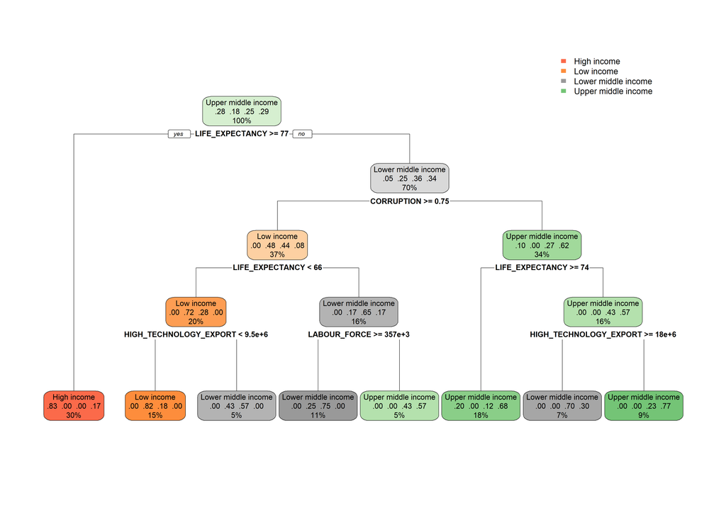

```r
# plot the tree with option 104 for probability
rpart.plot(ctree, extra = 104)
```

### 3.2.2 Classification Tree in Numbers

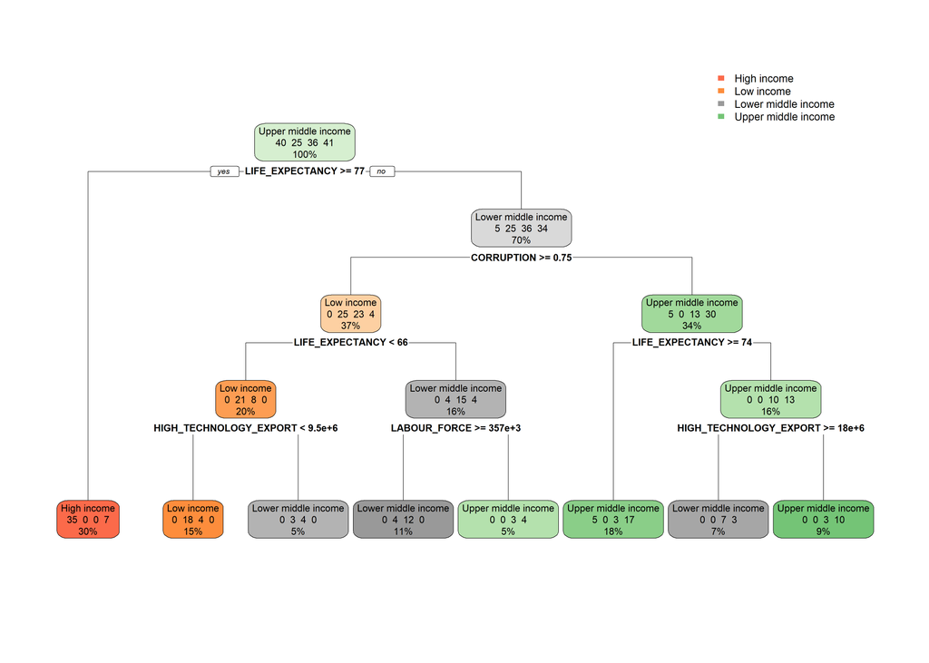

```r
# plot the tree with option 101 for numbers
rpart.plot(ctree, extra = 101)
```

## 3.3 Print classification Tree

```r
print(ctree)
```

```
## n= 142
##
## node), split, n, loss, yval, (yprob)
##       * denotes terminal node
##
##  1) root 142 101 Upper middle income (0.28169014 0.17605634 0.25352113 0.28873239)
##    2) LIFE_EXPECTANCY>=76.6445 42   7 High income (0.83333333 0.00000000 0.00000000 0.16666667) *
##    3) LIFE_EXPECTANCY< 76.6445 100  64 Lower middle income (0.05000000 0.25000000 0.36000000 0.34000000)
##      6) CORRUPTION>=0.75 52  27 Low income (0.00000000 0.48076923 0.44230769 0.07692308)
##       12) LIFE_EXPECTANCY< 66.4705 29   8 Low income (0.00000000 0.72413793 0.27586207 0.00000000)
##         24) HIGH_TECHNOLOGY_EXPORT< 9455222 22   4 Low income (0.00000000 0.81818182 0.18181818 0.00000000) *
##         25) HIGH_TECHNOLOGY_EXPORT>=9455222 7   3 Lower middle income (0.00000000 0.42857143 0.57142857 0.00000000) *
##       13) LIFE_EXPECTANCY>=66.4705 23   8 Lower middle income (0.00000000 0.17391304 0.65217391 0.17391304)
##         26) LABOUR_FORCE>=356509.5 16   4 Lower middle income (0.00000000 0.25000000 0.75000000 0.00000000) *
##         27) LABOUR_FORCE< 356509.5 7   3 Upper middle income (0.00000000 0.00000000 0.42857143 0.57142857) *
##      7) CORRUPTION< 0.75 48  18 Upper middle income (0.10416667 0.00000000 0.27083333 0.62500000)
##       14) LIFE_EXPECTANCY>=73.899 25   8 Upper middle income (0.20000000 0.00000000 0.12000000 0.68000000) *
##       15) LIFE_EXPECTANCY< 73.899 23  10 Upper middle income (0.00000000 0.00000000 0.43478261 0.56521739)
##         30) HIGH_TECHNOLOGY_EXPORT>=1.845504e+07 10   3 Lower middle income (0.00000000 0.00000000 0.70000000 0.30000000) *
##         31) HIGH_TECHNOLOGY_EXPORT< 1.845504e+07 13   3 Upper middle income (0.00000000 0.00000000 0.23076923 0.76923077) *
```

### 3.3.1 Classification tree discussion

Among of 7 variables we input into the model, only 4 were selected by the classification tree. It is not hard to understand life expectancy is one of the key variable which determines whether a country is high or low-income economy. The first two terminal nodes (with high-income and low-income label) are very straight forward and likely to identify. Due to these two group are the extreme one, it is easy to sort with selected variable(s). 30% of the population (data) directly go to the 1st terminal node with label of high-income group. It is determined by just 1 variable - life expectancy >=77. Regardless of some misclassifications for upper middle-income economies to the high-income economies, there is logical and valid reason that people in a higher-income economy most likely have a longer life due to better standard of living. The 2nd terminal node with label of low-income account for 15% of population. It is also clear cut that when all the negative factors appeared at once (corruption is high, life expectancy is short, and technology is poor), it goes directly to low-income economy.  
Next, CTREE has used high technology export to make different prediction on Rule 2 &3 and 4 & 8 .Generally low income countries process lower technology level, we do not expect they have much high tech output for export. However upper middle income countries would not have high tech export too as their manufacturing industries would not be booming as operation cost is high in rich countries. Therefore Lower middle income countries would have highest high tech export. It is matched with reality. The rest of the population (~55%) were distributed in 6 terminal nodes with the label of lower/upper-middle income. There are some misclassifications for lower middle-income economies to low-income economies by the nodes of labor force and export value. It implied threshold from aggregate value may not be applicable in this dataset. Per capita value shall be introduced.  
It is known that corruption level is higher for countries with lower income. CTREE tried to use this factor to classify low income and upper income level clearly. Unfortunately the misclassification rate is high using this pure factor.  
Overall the error rate is quite high (>20%). It may due to the reason that the selected variables are not significant to define the income group in the middle range (i.e. lower/upper middle). Yet there is no extreme misclassification (i.e. high income to be classified as low income and vice versa).

## 3.4 Decision Rule

```r
rpart.rules(ctree)
```

|  | INCOME_GROUP | Hig Low Low Upp |  |  |  |  |  |  |  |  |  |  |  |  |  |  |  |  |  |  |
| --- | --- | --- | --- | --- | --- | --- | --- | --- | --- | --- | --- | --- | --- | --- | --- | --- | --- | --- | --- | --- |
| 2 | High income | [.83 .00 .00 .17] | when | LIFE_EXPECTANCY | >= |  |  | 77 |  |  |  |  |  |  |  |  |  |  |  |  |
| 24 | Low income | [.00 .82 .18 .00] | when | LIFE_EXPECTANCY | < | 66 |  |  | & | CORRUPTION | >= | 0.75 | & | HIGH_TECHNOLOGY_EXPORT | < | 9.5e+06 |  |  |  |  |
| 25 | Lower middle income | [.00 .43 .57 .00] | when | LIFE_EXPECTANCY | < | 66 |  |  | & | CORRUPTION | >= | 0.75 | & | HIGH_TECHNOLOGY_EXPORT | >= | 9.5e+06 |  |  |  |  |
| 30 | Lower middle income | [.00 .00 .70 .30] | when | LIFE_EXPECTANCY | < | 74 |  |  | & | CORRUPTION | < | 0.75 | & | HIGH_TECHNOLOGY_EXPORT | >= | 1.8e+07 |  |  |  |  |
| 26 | Lower middle income | [.00 .25 .75 .00] | when | LIFE_EXPECTANCY | is | 66 | to | 77 | & | CORRUPTION | >= | 0.75 |  |  |  |  | & | LABOUR_FORCE | >= | 356510 |
| 27 | Upper middle income | [.00 .00 .43 .57] | when | LIFE_EXPECTANCY | is | 66 | to | 77 | & | CORRUPTION | >= | 0.75 |  |  |  |  | & | LABOUR_FORCE | < | 356510 |
| 14 | Upper middle income | [.20 .00 .12 .68] | when | LIFE_EXPECTANCY | is | 74 | to | 77 | & | CORRUPTION | < | 0.75 |  |  |  |  |  |  |  |  |
| 31 | Upper middle income | [.00 .00 .23 .77] | when | LIFE_EXPECTANCY | < | 74 |  |  | & | CORRUPTION | < | 0.75 | & | HIGH_TECHNOLOGY_EXPORT | < | 1.8e+07 |  |  |  |  |

R1: If Life Expectancy > 77 then HIGH INCOME (35/0/0/7)

R2: If Life expectancy < 66 and Corruption level >0.75 and Export is less than 9.45 million then LOW INCOME (0/18/4/0)

R3: If Life expectancy < 66 and Corruption level >0.75 and Export is more than 9.45million then LOW MIDDLE INCOME (0/3/4/0)

R5: If Life Expectancy is in between 66 vs 77 and Corruption level >0. 75 and Labor force is more than 356,510 then LOW MIDDLE INCOME (0/4/12/0)

R6: If Life Expectancy is in between 66 vs 77 and Corruption level >0. 75 and Labor force is less than 356,510 then UPPER MIDDLE INCOME (0/0/3/4)

R8: If Life Expectancy is < 74 and Corruption level < 0. 75 and export level is less than 18 million then UPPER MIDDLE INCOME (0/0/3/10)

## 3.5 Support, Confident and Capture of the Classification Tree

Classification Tree Explanatory Power

| Rule | Support | Confident | Capture |
| --- | --- | --- | --- |
| 1 | 0.2958 | 0.8333 | 0.8750 |
| 2 | 0.1549 | 0.8182 | 0.7200 |
| 3 | 0.0493 | 0.5714 | 0.1111 |
| 4 | 0.0704 | 0.7000 | 0.1944 |
| 5 | 0.1127 | 0.7500 | 0.3333 |
| 6 | 0.0493 | 0.5714 | 0.0976 |
| 7 | 0.1761 | 0.6800 | 0.4146 |
| 8 | 0.0915 | 0.7692 | 0.2439 |

Rule 1 and 2 have better predictive power with more than 80% confident level.

## 3.6 Investigate the complexity plot

```r
printcp(ctree)
```

```
##
## Classification tree:
## rpart(formula = INCOME_GROUP ~ REGION + GDP + LABOUR_FORCE +
##     LIFE_EXPECTANCY + MILITARY_EXPENSE + HIGH_TECHNOLOGY_EXPORT +
##     CORRUPTION, data = train, method = "class", control = rpart.control(cp = 0))
##
## Variables actually used in tree construction:
## [1] CORRUPTION             HIGH_TECHNOLOGY_EXPORT LABOUR_FORCE           LIFE_EXPECTANCY
##
## Root node error: 101/142 = 0.71127
##
## n= 142
##
##         CP nsplit rel error  xerror     xstd
## 1 0.297030      0   1.00000 1.09901 0.048739
## 2 0.188119      1   0.70297 0.75248 0.058845
## 3 0.108911      2   0.51485 0.60396 0.058404
## 4 0.019802      3   0.40594 0.50495 0.056603
## 5 0.009901      5   0.36634 0.50495 0.056603
## 6 0.000000      7   0.34653 0.53465 0.057276
```

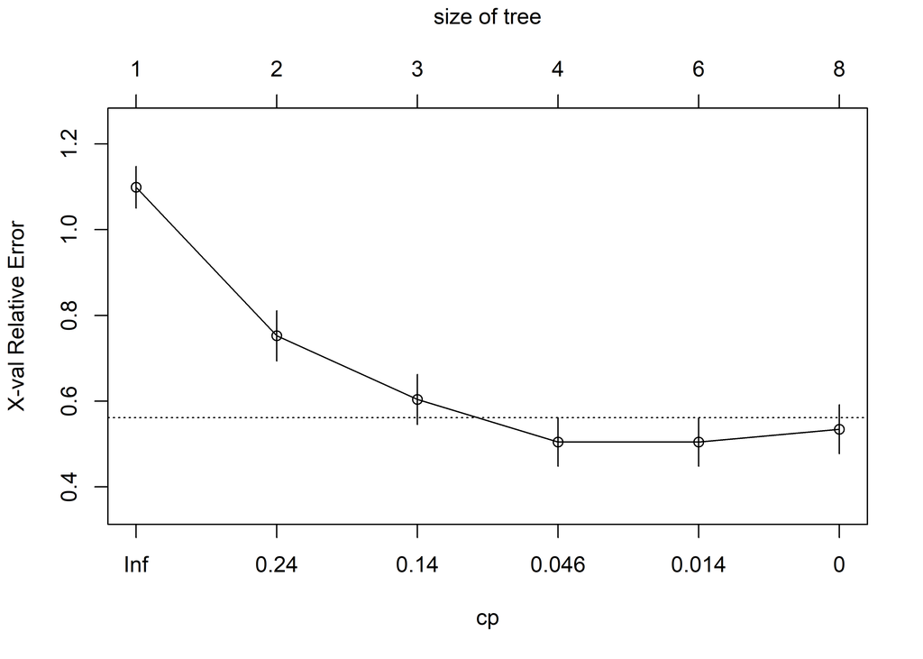

```r
plotcp(ctree)
```

Cost-complexity is minimum at 0.046.

# 4 Prediction

## 4.1 Prediction in training dataset

```r
predict_train2 <- predict(ctree, train, type = "class")
table(predict_train2, train$INCOME_GROUP)
```

```
##
## predict_train2        High income Low income Lower middle income Upper middle income
##   High income                  35          0                   0                   7
##   Low income                    0         18                   4                   0
##   Lower middle income           0          7                  23                   3
##   Upper middle income           5          0                   9                  31
```

## 4.2 Prediction in testing dataset

```r
predict_test2 <- predict(ctree, test, type = "class")
table(predict_test2, test$INCOME_GROUP)
```

```
##
## predict_test2         High income Low income Lower middle income Upper middle income
##   High income                  11          0                   0                   1
##   Low income                    0          5                   1                   0
##   Lower middle income           0          0                   4                   3
##   Upper middle income           3          0                   3                   4
```

## 4.3 Accuracy

```r
base_accuracy <- mean(predict_test2 == test$INCOME_GROUP)
(base_accuracy)
```

```
## [1] 0.6857143
```

## 4.4 Discussion on the predictions

The file “world.csv” contains the information about the income level of 177 countries. We randomly sampled 142 countries (about 80%) as our training data and remaining 35 countries as testing data. From the training set, there is 35 countries correctly classified as HIGH INCOME, 18 countries are LOW INCOME, 23 countries are LOWER MIDDLE INCOME and 31 countries are UPPER MIDDLE INCOME. There are total 35 errors (7+4+10+14) out of 142 countries in the training dataset, the error rate is 35/142=24.65% . If we adopt this model, we will have optimistic prediction that more countries are wealthy in the world.

Results on the prediction of training data

| Income.Group | Overall.Prediction | X.N.142. | Accurate.Prediction | X.N.107. | Training.dataset | X.N.142..1 | Reality | X.N.177. |
| --- | --- | --- | --- | --- | --- | --- | --- | --- |
| High Income | 42 | 29.58% | 35 | 32.71% | 40 | 28.17% | 54 | 30.51% |
| Low Income | 22 | 15.49% | 18 | 16.82% | 25 | 17.61% | 30 | 16.95% |
| Lower Middle | 33 | 23.24% | 23 | 21.50% | 36 | 25.35% | 44 | 24.86% |
| Upper Middle | 45 | 31.69% | 31 | 28.97% | 41 | 28.87% | 49 | 27.68% |
| Total | 142 | 100.00% | 107 | 100.00% | 142 | 100.00% | 177 | 100.00% |

[output not shown]

Since the error rate of the testing data is 27 % greater than the training data, there might be a chance that the model is over fitted. The rules selected from the model is used to fit the outlier and noise of the training dataset instead of market data. The predictive power will be weakened. To better valuate the model efficiency and minimize error rate, we may increase the sample size. Unfortunately, there is insufficient data on market (Number of countries) for us to collect and consolidate.